# Verzani Problem Set

## Problem 14.2

For the `homeprice` data set, how do the coefficients change if you force the intercept, $\beta_0$ to be $0$? (Use a $0$ or $-1$ in the model formula notation.) Does it make any sense for this model to have no intercept term?

### Solution

First let us see the model with intercept

```r
> model.all <- lm(list ~ half + full + bedrooms + rooms + neighborhood)
> summary(model.all)

Call:
lm(formula = list ~ half + full + bedrooms + rooms + neighborhood)

Residuals:
    Min      1Q  Median      3Q     Max
-60.788 -28.776   4.351  23.859  62.720

Coefficients:
             Estimate Std. Error t value Pr(>|t|)
(Intercept)  -144.544     36.026  -4.012 0.000546 ***
half           45.556     12.397   3.675 0.001257 **
full           32.125     13.427   2.392 0.025293 *
bedrooms       18.446     17.197   1.073 0.294572
rooms           7.126     10.033   0.710 0.484661
neighborhood   77.430      9.737   7.952 4.75e-08 ***
---
Signif. codes:  0 '***' 0.001 '**' 0.01 '*' 0.05 '.' 0.1 ' ' 1

Residual standard error: 37.97 on 23 degrees of freedom
Multiple R-squared:  0.9183,    Adjusted R-squared:  0.9006
F-statistic: 51.74 on 5 and 23 DF,  p-value: 9.358e-12
```

Let us see now the coefficients without intercept

```r
> model.all <- lm(list ~ 0 + half + full + bedrooms + rooms + neighborhood)
> summary(model.all)

Call:
lm(formula = list ~ 0 + half + full + bedrooms + rooms + neighborhood)

Residuals:
     Min       1Q   Median       3Q      Max
-118.547  -27.898   -0.298   25.814   68.001

Coefficients:
             Estimate Std. Error t value Pr(>|t|)
half            54.05      15.59   3.467   0.0020 **
full            36.76      17.07   2.153   0.0416 *
bedrooms        17.76      21.95   0.809   0.4263
rooms          -10.40      11.53  -0.902   0.3760
neighborhood    69.11      12.14   5.691 7.31e-06 ***
---
Signif. codes:  0 '***' 0.001 '**' 0.01 '*' 0.05 '.' 0.1 ' ' 1

Residual standard error: 48.46 on 24 degrees of freedom
Multiple R-squared:  0.9783,    Adjusted R-squared:  0.9738
F-statistic: 216.3 on 5 and 24 DF,  p-value: < 2.2e-16
```

or

```r
> model.all <- lm(list ~ -1 + half + full + bedrooms + rooms + neighborhood)
> summary(model.all)

Call:
lm(formula = list ~ -1 + half + full + bedrooms + rooms + neighborhood)

Residuals:
     Min       1Q   Median       3Q      Max
-118.547  -27.898   -0.298   25.814   68.001

Coefficients:
             Estimate Std. Error t value Pr(>|t|)
half            54.05      15.59   3.467   0.0020 **
full            36.76      17.07   2.153   0.0416 *
bedrooms        17.76      21.95   0.809   0.4263
rooms          -10.40      11.53  -0.902   0.3760
neighborhood    69.11      12.14   5.691 7.31e-06 ***
---
Signif. codes:  0 '***' 0.001 '**' 0.01 '*' 0.05 '.' 0.1 ' ' 1

Residual standard error: 48.46 on 24 degrees of freedom
Multiple R-squared:  0.9783,    Adjusted R-squared:  0.9738
F-statistic: 216.3 on 5 and 24 DF,  p-value: < 2.2e-16
```

When we compare the adjusted $R^2$ for the models with and without intercept, we observe that the model without intercept is better.

Let us now improve the model. In the first model the intercept is statistically significant. In the last model the independent variables `bedrooms` and `rooms` are not statistically significant. Therefore, let us now exclude one of them.

```r
> model.all <- lm(list ~ half + full + bedrooms + neighborhood)
> summary(model.all)

Call:
lm(formula = list ~ half + full + bedrooms + neighborhood)

Residuals:
    Min      1Q  Median      3Q     Max
-57.757 -30.942   4.129  27.084  58.609

Coefficients:
             Estimate Std. Error t value Pr(>|t|)
(Intercept)  -133.404     32.096  -4.156 0.000355 ***
half           48.094     11.748   4.094 0.000416 ***
full           33.355     13.177   2.531 0.018328 *
bedrooms       28.446      9.775   2.910 0.007675 **
neighborhood   79.057      9.366   8.441  1.2e-08 ***
---
Signif. codes:  0 '***' 0.001 '**' 0.01 '*' 0.05 '.' 0.1 ' ' 1

Residual standard error: 37.57 on 24 degrees of freedom
Multiple R-squared:  0.9166,    Adjusted R-squared:  0.9026
F-statistic: 65.91 on 4 and 24 DF,  p-value: 1.367e-12
```

All the coefficients in this model are statistically significant.

From practical point of view as far as when we do not buy anything we do not pay anything it is reasonable, however, the intercept to be $\beta_0 = 0$.

## Problem 14.3

For the `homeprice` data set, what is the effect of `neighborhood` on the difference between `sale` price and `list` price? Do nicer `neighborhood`s mean it is more likely to have a house go over the asking price?

### Solution

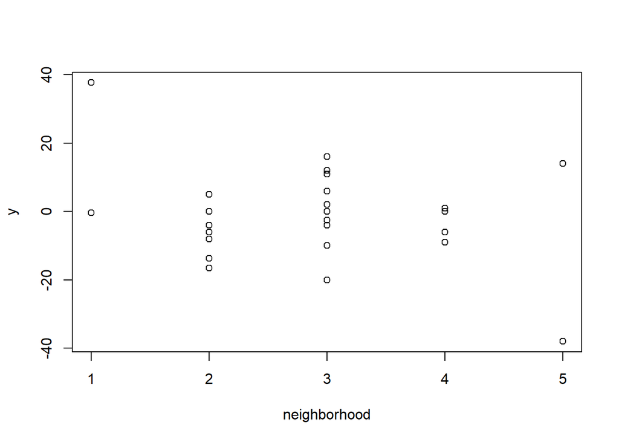

```r
> y <- sale - list
> model.diff <- lm(y ~ neighborhood)
> summary(model.diff)

Call:
lm(formula = y ~ neighborhood)

Residuals:
   Min     1Q Median     3Q    Max
-30.05  -7.50  -0.85   5.80  33.05

Coefficients:
             Estimate Std. Error t value Pr(>|t|)
(Intercept)     7.800      7.435   1.049    0.303
neighborhood   -3.150      2.428  -1.298    0.205

Residual standard error: 13 on 27 degrees of freedom
Multiple R-squared:  0.0587,    Adjusted R-squared:  0.02383
F-statistic: 1.684 on 1 and 27 DF,  p-value: 0.2054
> plot(neighborhood, y)
> abline(y ~ neighborhood)
```

When the points for `neighborhood` increase with $1$, the difference $sale - list$ decreases with $3\ 150\$$. This effect, however, is not statistically significant.

```r
> table(neighborhood)
neighborhood
 1  2  3  4  5
 2  8 12  5  2
```

Do nicer `neighborhood`s mean it is more likely to have a house go over the asking price?

$H_0 : \mathbb{E}(sale - list\ |\ neighborhood > 3) = 0$

$H_A : \mathbb{E}(sale - list\ |\ neighborhood > 3) > 0$

```r
> yall <- sale - list
> y <- yall[neighborhood > 3]
> n <- length(y)
> temp <- (mean(y) - 0) / (sd(y) / sqrt(n)); temp
[1] -0.8663419
> pvalue <- pt(temp, n - 1, lower.tail = FALSE); pvalue
[1] 0.7902036
```

The $p-value = 0.7902036 > \alpha = 0.05$, therefore, we have no evidence to reject $H_0$. The nicer neighborhoods does not obligatory mean that it is more likely to have a house go over the asking price.

## Problem 14.5

For the `babies` data set, do a multiple regression of birthweight(`wt`) with regressors the mothers `age`, weight `wt1` and height `ht`. What is the value of $R^2$? What are the coefficients? Do any variables appear to be $0$?

### Solution

```r
> head(babies)
   id pluralty outcome date gestation sex  wt parity race age ed ht wt1 drace
1  15        5       1 1411       284   1 120      1    8  27  5 62 100     8
2  20        5       1 1499       282   1 113      2    0  33  5 64 135     0
3  58        5       1 1576       279   1 128      1    0  28  2 64 115     5
4  61        5       1 1504       999   1 123      2    0  36  5 69 190     3
5  72        5       1 1425       282   1 108      1    0  23  5 67 125     0
6 100        5       1 1673       286   1 136      4    0  25  2 62  93     3
  dage ded dht dwt marital inc smoke time number
1   31   5  65 110       1   1     0    0      0
2   38   5  70 148       1   4     0    0      0
3   32   1  99 999       1   2     1    1      1
4   43   4  68 197       1   8     3    5      5
5   24   5  99 999       1   1     1    1      5
6   28   2  64 130       1   4     2    2      2
> ls(babies)
 [1] "age"       "dage"      "date"      "ded"       "dht"       "drace"
 [7] "dwt"       "ed"        "gestation" "ht"        "id"        "inc"
[13] "marital"   "number"    "outcome"   "parity"    "pluralty"  "race"
[19] "sex"       "smoke"     "time"      "wt"        "wt1"
> attach(babies)
> n <- length(wt); n
[1] 1236
```

This data frame contains $1\ 236$ observations. We need the following ones

`wt` - birth weight in ounces (where `999` means unknown)

`ht` - mother’s height in inches to the last completed inch (where `99` means unknown)

`age` - mother’s age in years at termination of pregnancy, (where `99` means unknown)

`wt1` - mother pregnancy weight in pounds, (where `999` means unknown)

Let us build up the multiple regression model

```r
> data <- babies[wt != 999 && ht != 99 && age != 99 && wt1 != 999, ]
> View(data)
> model.all <- lm(data$wt ~ data$age + data$wt1 + data$ht)
> summary(model.all)

Call:
lm(formula = data$wt ~ data$age + data$wt1 + data$ht)

Residuals:
    Min      1Q  Median      3Q     Max
-65.360 -11.304   0.421  11.425  56.682

Coefficients:
             Estimate Std. Error t value Pr(>|t|)
(Intercept) 84.456722   7.826997  10.790  < 2e-16 ***
data$age     0.069360   0.079916   0.868    0.386
data$wt1    -0.005697   0.004361  -1.306    0.192
data$ht      0.527277   0.122477   4.305  1.8e-05 ***
---
Signif. codes:  0 '***' 0.001 '**' 0.01 '*' 0.05 '.' 0.1 ' ' 1

Residual standard error: 18.1 on 1232 degrees of freedom
Multiple R-squared:  0.01765,   Adjusted R-squared:  0.01526
F-statistic: 7.378 on 3 and 1232 DF,  p-value: 6.69e-05
```

The model is
$$wt = 84.456722 + 0.069360\ age - 0.005697\ wt1 + 0.527277\ ht$$

The variables `age` and `wt1` are not statistically significant. Adjusted $R^2 = 0.01526$ is small therefore the model is not quite good.